# Risk Factor Analysis

## Outcome Variable

**Outcome Variable:** sstunted

## Predictor Variables

**Intervention Variable:** single

**Adjustment Set:**

- arm
- W_mage
- W_fage
- meducyrs
- feducyrs
- W_mhtcm
- W_mwtkg
- W_mbmi
- delta_W_mage
- delta_W_fage
- delta_meducyrs
- delta_feducyrs
- delta_W_mhtcm
- delta_W_mwtkg
- delta_W_mbmi

## Stratifying Variables

The analysis was stratified on these variable(s):

- agecat
- studyid
- country

## Data Summary

| agecat | studyid | country | single | sstunted | n_cell | n |
| --- | --- | --- | --- | --- | --- | --- |
| Birth | ki0047075b-MAL-ED | BANGLADESH | 0 | 0 | 248 | 257 |
| Birth | ki0047075b-MAL-ED | BANGLADESH | 0 | 1 | 9 | 257 |
| Birth | ki0047075b-MAL-ED | BANGLADESH | 1 | 0 | 0 | 257 |
| Birth | ki0047075b-MAL-ED | BANGLADESH | 1 | 1 | 0 | 257 |
| Birth | ki0047075b-MAL-ED | BRAZIL | 0 | 0 | 160 | 191 |
| Birth | ki0047075b-MAL-ED | BRAZIL | 0 | 1 | 6 | 191 |
| Birth | ki0047075b-MAL-ED | BRAZIL | 1 | 0 | 23 | 191 |
| Birth | ki0047075b-MAL-ED | BRAZIL | 1 | 1 | 2 | 191 |
| Birth | ki0047075b-MAL-ED | INDIA | 0 | 0 | 198 | 205 |
| Birth | ki0047075b-MAL-ED | INDIA | 0 | 1 | 7 | 205 |
| Birth | ki0047075b-MAL-ED | INDIA | 1 | 0 | 0 | 205 |
| Birth | ki0047075b-MAL-ED | INDIA | 1 | 1 | 0 | 205 |
| Birth | ki0047075b-MAL-ED | NEPAL | 0 | 0 | 167 | 173 |
| Birth | ki0047075b-MAL-ED | NEPAL | 0 | 1 | 6 | 173 |
| Birth | ki0047075b-MAL-ED | NEPAL | 1 | 0 | 0 | 173 |
| Birth | ki0047075b-MAL-ED | NEPAL | 1 | 1 | 0 | 173 |
| Birth | ki0047075b-MAL-ED | PERU | 0 | 0 | 247 | 287 |
| Birth | ki0047075b-MAL-ED | PERU | 0 | 1 | 6 | 287 |
| Birth | ki0047075b-MAL-ED | PERU | 1 | 0 | 32 | 287 |
| Birth | ki0047075b-MAL-ED | PERU | 1 | 1 | 2 | 287 |
| Birth | ki0047075b-MAL-ED | SOUTH AFRICA | 0 | 0 | 146 | 262 |
| Birth | ki0047075b-MAL-ED | SOUTH AFRICA | 0 | 1 | 0 | 262 |
| Birth | ki0047075b-MAL-ED | SOUTH AFRICA | 1 | 0 | 114 | 262 |
| Birth | ki0047075b-MAL-ED | SOUTH AFRICA | 1 | 1 | 2 | 262 |
| Birth | ki0047075b-MAL-ED | TANZANIA, UNITED REPUBLIC OF | 0 | 0 | 111 | 123 |
| Birth | ki0047075b-MAL-ED | TANZANIA, UNITED REPUBLIC OF | 0 | 1 | 6 | 123 |
| Birth | ki0047075b-MAL-ED | TANZANIA, UNITED REPUBLIC OF | 1 | 0 | 6 | 123 |
| Birth | ki0047075b-MAL-ED | TANZANIA, UNITED REPUBLIC OF | 1 | 1 | 0 | 123 |
| Birth | ki1119695-PROBIT | BELARUS | 0 | 0 | 13338 | 13884 |
| Birth | ki1119695-PROBIT | BELARUS | 0 | 1 | 5 | 13884 |

[output cut: 126 more lines]

The following strata were considered:

- agecat: 24 months, studyid: ki0047075b-MAL-ED, country: BANGLADESH
- agecat: 24 months, studyid: ki0047075b-MAL-ED, country: BRAZIL
- agecat: 24 months, studyid: ki0047075b-MAL-ED, country: INDIA
- agecat: 24 months, studyid: ki0047075b-MAL-ED, country: NEPAL
- agecat: 24 months, studyid: ki0047075b-MAL-ED, country: PERU
- agecat: 24 months, studyid: ki0047075b-MAL-ED, country: SOUTH AFRICA
- agecat: 24 months, studyid: ki0047075b-MAL-ED, country: TANZANIA, UNITED REPUBLIC OF
- agecat: 24 months, studyid: ki1066203-TanzaniaChild2, country: TANZANIA, UNITED REPUBLIC OF
- agecat: 24 months, studyid: ki1119695-PROBIT, country: BELARUS
- agecat: 24 months, studyid: ki1126311-ZVITAMBO, country: ZIMBABWE
- agecat: 24 months, studyid: ki1135781-COHORTS, country: GUATEMALA
- agecat: 24 months, studyid: ki1135781-COHORTS, country: INDIA
- agecat: 24 months, studyid: ki1135781-COHORTS, country: PHILIPPINES
- agecat: 6 months, studyid: ki0047075b-MAL-ED, country: BANGLADESH
- agecat: 6 months, studyid: ki0047075b-MAL-ED, country: BRAZIL
- agecat: 6 months, studyid: ki0047075b-MAL-ED, country: INDIA
- agecat: 6 months, studyid: ki0047075b-MAL-ED, country: NEPAL
- agecat: 6 months, studyid: ki0047075b-MAL-ED, country: PERU
- agecat: 6 months, studyid: ki0047075b-MAL-ED, country: SOUTH AFRICA
- agecat: 6 months, studyid: ki0047075b-MAL-ED, country: TANZANIA, UNITED REPUBLIC OF
- agecat: 6 months, studyid: ki1066203-TanzaniaChild2, country: TANZANIA, UNITED REPUBLIC OF
- agecat: 6 months, studyid: ki1112895-Guatemala BSC, country: GUATEMALA
- agecat: 6 months, studyid: ki1119695-PROBIT, country: BELARUS
- agecat: 6 months, studyid: ki1126311-ZVITAMBO, country: ZIMBABWE
- agecat: 6 months, studyid: ki1135781-COHORTS, country: GUATEMALA
- agecat: 6 months, studyid: ki1135781-COHORTS, country: INDIA
- agecat: 6 months, studyid: ki1135781-COHORTS, country: PHILIPPINES
- agecat: Birth, studyid: ki0047075b-MAL-ED, country: BANGLADESH
- agecat: Birth, studyid: ki0047075b-MAL-ED, country: BRAZIL
- agecat: Birth, studyid: ki0047075b-MAL-ED, country: INDIA
- agecat: Birth, studyid: ki0047075b-MAL-ED, country: NEPAL
- agecat: Birth, studyid: ki0047075b-MAL-ED, country: PERU
- agecat: Birth, studyid: ki0047075b-MAL-ED, country: SOUTH AFRICA
- agecat: Birth, studyid: ki0047075b-MAL-ED, country: TANZANIA, UNITED REPUBLIC OF
- agecat: Birth, studyid: ki1119695-PROBIT, country: BELARUS
- agecat: Birth, studyid: ki1126311-ZVITAMBO, country: ZIMBABWE
- agecat: Birth, studyid: ki1135781-COHORTS, country: GUATEMALA
- agecat: Birth, studyid: ki1135781-COHORTS, country: INDIA
- agecat: Birth, studyid: ki1135781-COHORTS, country: PHILIPPINES

### Dropped Strata

Some strata were dropped due to rare outcomes:

- agecat: Birth, studyid: ki0047075b-MAL-ED, country: BANGLADESH
- agecat: Birth, studyid: ki0047075b-MAL-ED, country: BRAZIL
- agecat: Birth, studyid: ki0047075b-MAL-ED, country: INDIA
- agecat: Birth, studyid: ki0047075b-MAL-ED, country: NEPAL
- agecat: Birth, studyid: ki0047075b-MAL-ED, country: PERU
- agecat: Birth, studyid: ki0047075b-MAL-ED, country: SOUTH AFRICA
- agecat: Birth, studyid: ki0047075b-MAL-ED, country: TANZANIA, UNITED REPUBLIC OF
- agecat: Birth, studyid: ki1119695-PROBIT, country: BELARUS
- agecat: Birth, studyid: ki1135781-COHORTS, country: GUATEMALA
- agecat: Birth, studyid: ki1135781-COHORTS, country: INDIA
- agecat: Birth, studyid: ki1135781-COHORTS, country: PHILIPPINES
- agecat: 6 months, studyid: ki0047075b-MAL-ED, country: BANGLADESH
- agecat: 6 months, studyid: ki0047075b-MAL-ED, country: BRAZIL
- agecat: 6 months, studyid: ki0047075b-MAL-ED, country: INDIA
- agecat: 6 months, studyid: ki0047075b-MAL-ED, country: NEPAL
- agecat: 6 months, studyid: ki0047075b-MAL-ED, country: PERU
- agecat: 6 months, studyid: ki0047075b-MAL-ED, country: SOUTH AFRICA
- agecat: 6 months, studyid: ki0047075b-MAL-ED, country: TANZANIA, UNITED REPUBLIC OF
- agecat: 6 months, studyid: ki1066203-TanzaniaChild2, country: TANZANIA, UNITED REPUBLIC OF
- agecat: 6 months, studyid: ki1135781-COHORTS, country: INDIA
- agecat: 6 months, studyid: ki1135781-COHORTS, country: PHILIPPINES
- agecat: 24 months, studyid: ki0047075b-MAL-ED, country: BANGLADESH
- agecat: 24 months, studyid: ki0047075b-MAL-ED, country: BRAZIL
- agecat: 24 months, studyid: ki0047075b-MAL-ED, country: INDIA
- agecat: 24 months, studyid: ki0047075b-MAL-ED, country: NEPAL
- agecat: 24 months, studyid: ki0047075b-MAL-ED, country: PERU
- agecat: 24 months, studyid: ki0047075b-MAL-ED, country: TANZANIA, UNITED REPUBLIC OF
- agecat: 24 months, studyid: ki1066203-TanzaniaChild2, country: TANZANIA, UNITED REPUBLIC OF
- agecat: 24 months, studyid: ki1119695-PROBIT, country: BELARUS
- agecat: 24 months, studyid: ki1135781-COHORTS, country: INDIA

## Methods Detail

We’re interested in the causal parameters $E[Y_a]$ for all values of $a \in \mathcal{A}$. These parameters represent the mean outcome if, possibly contrary to fact, we intervened to set all units to have $A=a$. Under the randomization and positivity assumptions, these are identified by the statistical parameters $\psi_a=E_W[E_{Y|A,W}(Y|A=a,W)]$. In addition, we’re interested in the mean of $Y$, $E[Y]$ under no intervention (the observed mean). We will estimate these parameters by using SuperLearner to fit the relevant likelihood factors – $E_{Y|A,W}(Y|A=a,W)$ and $p(A=a|W)$, and then updating our likelihood fit using a joint TMLE.

For unadjusted analyses ($W=\{\}$), initial likelihoods were estimated using Lrnr_glm to estimate the simple $E(Y|A)$ and Lrnr_mean to estimate $p(A)$. For adjusted analyses, a small library containing Lrnr_glmnet, Lrnr_xgboost, and Lrnr_mean was used.

Having estimated these parameters, we will then use the delta method to estimate relative risks and attributable risks relative to a prespecified baseline level of $A$.

# Results Detail

## Results Plots

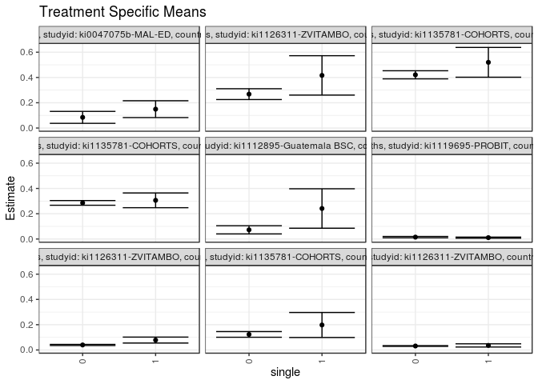

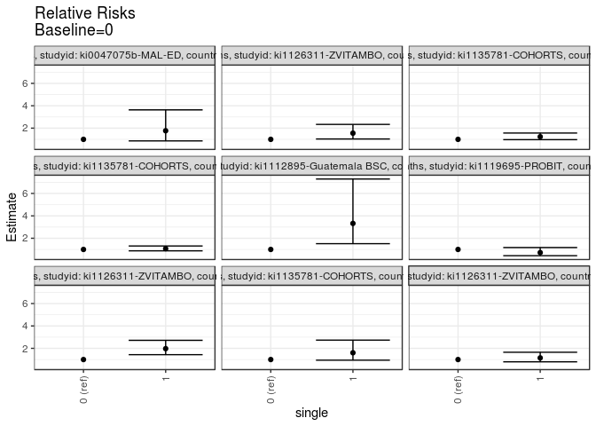

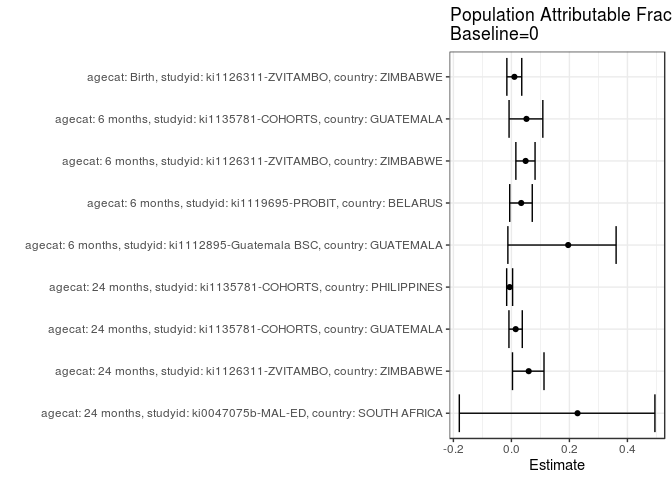

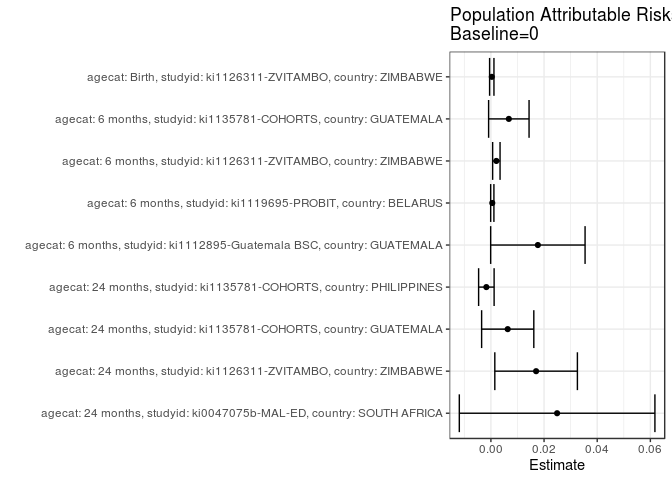

## Results Table

### Parameter: TSM

| agecat | studyid | country | intervention_level | baseline_level | estimate | ci_lower | ci_upper |
| --- | --- | --- | --- | --- | --- | --- | --- |
| Birth | ki1126311-ZVITAMBO | ZIMBABWE | 0 | NA | 0.0314743 | 0.0284591 | 0.0344896 |
| Birth | ki1126311-ZVITAMBO | ZIMBABWE | 1 | NA | 0.0361344 | 0.0234754 | 0.0487935 |
| 6 months | ki1112895-Guatemala BSC | GUATEMALA | 0 | NA | 0.0725806 | 0.0402320 | 0.1049293 |
| 6 months | ki1112895-Guatemala BSC | GUATEMALA | 1 | NA | 0.2413793 | 0.0853534 | 0.3974052 |
| 6 months | ki1119695-PROBIT | BELARUS | 0 | NA | 0.0148959 | 0.0096026 | 0.0201892 |
| 6 months | ki1119695-PROBIT | BELARUS | 1 | NA | 0.0107313 | 0.0062990 | 0.0151635 |
| 6 months | ki1126311-ZVITAMBO | ZIMBABWE | 0 | NA | 0.0396940 | 0.0353550 | 0.0440329 |
| 6 months | ki1126311-ZVITAMBO | ZIMBABWE | 1 | NA | 0.0783693 | 0.0548655 | 0.1018732 |
| 6 months | ki1135781-COHORTS | GUATEMALA | 0 | NA | 0.1231510 | 0.1006942 | 0.1456078 |
| 6 months | ki1135781-COHORTS | GUATEMALA | 1 | NA | 0.1977502 | 0.0987744 | 0.2967260 |
| 24 months | ki0047075b-MAL-ED | SOUTH AFRICA | 0 | NA | 0.0843300 | 0.0370052 | 0.1316547 |
| 24 months | ki0047075b-MAL-ED | SOUTH AFRICA | 1 | NA | 0.1492364 | 0.0826495 | 0.2158233 |
| 24 months | ki1126311-ZVITAMBO | ZIMBABWE | 0 | NA | 0.2680790 | 0.2253011 | 0.3108569 |
| 24 months | ki1126311-ZVITAMBO | ZIMBABWE | 1 | NA | 0.4164117 | 0.2605502 | 0.5722733 |
| 24 months | ki1135781-COHORTS | GUATEMALA | 0 | NA | 0.4211175 | 0.3891533 | 0.4530817 |
| 24 months | ki1135781-COHORTS | GUATEMALA | 1 | NA | 0.5198096 | 0.4019599 | 0.6376594 |
| 24 months | ki1135781-COHORTS | PHILIPPINES | 0 | NA | 0.2856476 | 0.2670618 | 0.3042334 |
| 24 months | ki1135781-COHORTS | PHILIPPINES | 1 | NA | 0.3059753 | 0.2476114 | 0.3643392 |

### Parameter: E(Y)

| agecat | studyid | country | intervention_level | baseline_level | estimate | ci_lower | ci_upper |
| --- | --- | --- | --- | --- | --- | --- | --- |
| Birth | ki1126311-ZVITAMBO | ZIMBABWE | NA | NA | 0.0318037 | 0.0288729 | 0.0347345 |
| 6 months | ki1112895-Guatemala BSC | GUATEMALA | NA | NA | 0.0902527 | 0.0564475 | 0.1240580 |
| 6 months | ki1119695-PROBIT | BELARUS | NA | NA | 0.0154178 | 0.0100323 | 0.0208033 |
| 6 months | ki1126311-ZVITAMBO | ZIMBABWE | NA | NA | 0.0417423 | 0.0374303 | 0.0460543 |
| 6 months | ki1135781-COHORTS | GUATEMALA | NA | NA | 0.1298992 | 0.1078368 | 0.1519617 |
| 24 months | ki0047075b-MAL-ED | SOUTH AFRICA | NA | NA | 0.1092437 | 0.0695290 | 0.1489584 |
| 24 months | ki1126311-ZVITAMBO | ZIMBABWE | NA | NA | 0.2850877 | 0.2436059 | 0.3265696 |
| 24 months | ki1135781-COHORTS | GUATEMALA | NA | NA | 0.4274432 | 0.3969638 | 0.4579226 |
| 24 months | ki1135781-COHORTS | PHILIPPINES | NA | NA | 0.2839404 | 0.2659568 | 0.3019240 |

### Parameter: RR

| agecat | studyid | country | intervention_level | baseline_level | estimate | ci_lower | ci_upper |
| --- | --- | --- | --- | --- | --- | --- | --- |
| Birth | ki1126311-ZVITAMBO | ZIMBABWE | 0 | 0 | 1.000000 | 1.0000000 | 1.000000 |
| Birth | ki1126311-ZVITAMBO | ZIMBABWE | 1 | 0 | 1.148060 | 0.7984237 | 1.650805 |
| 6 months | ki1112895-Guatemala BSC | GUATEMALA | 0 | 0 | 1.000000 | 1.0000000 | 1.000000 |
| 6 months | ki1112895-Guatemala BSC | GUATEMALA | 1 | 0 | 3.325671 | 1.5166712 | 7.292342 |
| 6 months | ki1119695-PROBIT | BELARUS | 0 | 0 | 1.000000 | 1.0000000 | 1.000000 |
| 6 months | ki1119695-PROBIT | BELARUS | 1 | 0 | 0.720417 | 0.4437725 | 1.169520 |
| 6 months | ki1126311-ZVITAMBO | ZIMBABWE | 0 | 0 | 1.000000 | 1.0000000 | 1.000000 |
| 6 months | ki1126311-ZVITAMBO | ZIMBABWE | 1 | 0 | 1.974339 | 1.4352440 | 2.715925 |
| 6 months | ki1135781-COHORTS | GUATEMALA | 0 | 0 | 1.000000 | 1.0000000 | 1.000000 |
| 6 months | ki1135781-COHORTS | GUATEMALA | 1 | 0 | 1.605754 | 0.9428410 | 2.734763 |
| 24 months | ki0047075b-MAL-ED | SOUTH AFRICA | 0 | 0 | 1.000000 | 1.0000000 | 1.000000 |
| 24 months | ki0047075b-MAL-ED | SOUTH AFRICA | 1 | 0 | 1.769672 | 0.8619021 | 3.633520 |
| 24 months | ki1126311-ZVITAMBO | ZIMBABWE | 0 | 0 | 1.000000 | 1.0000000 | 1.000000 |
| 24 months | ki1126311-ZVITAMBO | ZIMBABWE | 1 | 0 | 1.553317 | 1.0332264 | 2.335204 |
| 24 months | ki1135781-COHORTS | GUATEMALA | 0 | 0 | 1.000000 | 1.0000000 | 1.000000 |
| 24 months | ki1135781-COHORTS | GUATEMALA | 1 | 0 | 1.234358 | 0.9734479 | 1.565198 |
| 24 months | ki1135781-COHORTS | PHILIPPINES | 0 | 0 | 1.000000 | 1.0000000 | 1.000000 |
| 24 months | ki1135781-COHORTS | PHILIPPINES | 1 | 0 | 1.071163 | 0.8755981 | 1.310409 |

### Parameter: PAR

| agecat | studyid | country | intervention_level | baseline_level | estimate | ci_lower | ci_upper |
| --- | --- | --- | --- | --- | --- | --- | --- |
| Birth | ki1126311-ZVITAMBO | ZIMBABWE | 0 | NA | 0.0003293 | -0.0004872 | 0.0011458 |
| 6 months | ki1112895-Guatemala BSC | GUATEMALA | 0 | NA | 0.0176721 | -0.0000894 | 0.0354335 |
| 6 months | ki1119695-PROBIT | BELARUS | 0 | NA | 0.0005219 | -0.0000874 | 0.0011312 |
| 6 months | ki1126311-ZVITAMBO | ZIMBABWE | 0 | NA | 0.0020483 | 0.0006537 | 0.0034430 |
| 6 months | ki1135781-COHORTS | GUATEMALA | 0 | NA | 0.0067482 | -0.0008602 | 0.0143566 |
| 24 months | ki0047075b-MAL-ED | SOUTH AFRICA | 0 | NA | 0.0249137 | -0.0118856 | 0.0617131 |
| 24 months | ki1126311-ZVITAMBO | ZIMBABWE | 0 | NA | 0.0170087 | 0.0014715 | 0.0325460 |
| 24 months | ki1135781-COHORTS | GUATEMALA | 0 | NA | 0.0063257 | -0.0034923 | 0.0161438 |
| 24 months | ki1135781-COHORTS | PHILIPPINES | 0 | NA | -0.0017072 | -0.0046222 | 0.0012078 |

### Parameter: PAF

| agecat | studyid | country | intervention_level | baseline_level | estimate | ci_lower | ci_upper |
| --- | --- | --- | --- | --- | --- | --- | --- |
| Birth | ki1126311-ZVITAMBO | ZIMBABWE | 0 | NA | 0.0103547 | -0.0156390 | 0.0356831 |
| 6 months | ki1112895-Guatemala BSC | GUATEMALA | 0 | NA | 0.1958065 | -0.0121457 | 0.3610334 |
| 6 months | ki1119695-PROBIT | BELARUS | 0 | NA | 0.0338510 | -0.0057792 | 0.0719198 |
| 6 months | ki1126311-ZVITAMBO | ZIMBABWE | 0 | NA | 0.0490710 | 0.0154172 | 0.0815745 |
| 6 months | ki1135781-COHORTS | GUATEMALA | 0 | NA | 0.0519498 | -0.0080470 | 0.1083757 |
| 24 months | ki0047075b-MAL-ED | SOUTH AFRICA | 0 | NA | 0.2280564 | -0.1795706 | 0.4948188 |
| 24 months | ki1126311-ZVITAMBO | ZIMBABWE | 0 | NA | 0.0596614 | 0.0037623 | 0.1124239 |
| 24 months | ki1135781-COHORTS | GUATEMALA | 0 | NA | 0.0147990 | -0.0084583 | 0.0375200 |
| 24 months | ki1135781-COHORTS | PHILIPPINES | 0 | NA | -0.0060125 | -0.0162888 | 0.0041599 |